# Manual

Alba Colado Suarez

1/4/2022

Los metadatos siempre van al principio y se ponen entre guiones “—”

**echo** = true: dice que enseñe el codigo y tambien el texto - para visualizarlo en el codigo final En cada chunk puedes especificar concretamente, por ejemplo si no quieres que lo evalue (no lo corre) **eval** = false **warning** y **message** = false : para que solo te los enseñe en la consola

# Distintos tipos de tipografia

**negrita** *cursiva* subíndice<sub>1</sub> superíndice<sup>2</sup> Títulos: # primer nivel, ## segundo nivel… Listas y sublistas (*, -, +)

# Introduccion

```r
#install.packages("lattice")
library (lattice)
#demo (lattice)
```

# Programacion basica en R

Con el simbolo *<-* asignamos un objetos Con la letra *c* concatenamos numeros

```r
1+1
```

```
## [1] 2
```

```r
a = 1 + 1
a
```

```
## [1] 2
```

```r
a <- 1 + 1
b <- c(1,2)
sum(a,b)
```

```
## [1] 5
```

```r
str(b)
```

```
##  num [1:2] 1 2
```

```r
str(a)
```

```
##  num 2
```

Con las teclas rapidas *Control+Shift+R* abrimos un nuevo titulo de seccion

# Usando paquetes y librerias

```r
#install.packages("tidyverse")
library(tidyverse)
```

En R hay que tener en cuenta que cada *observacion* es una **fila** y cada *columna* una **variable**

```r
names(iris)
```

```
## [1] "Sepal.Length" "Sepal.Width"  "Petal.Length" "Petal.Width"  "Species"
```

```r
select(iris, Petal.Width)
```

```
##     Petal.Width
## 1           0.2
## 2           0.2
## 3           0.2
## 4           0.2
## 5           0.2
## 6           0.4
## 7           0.3
## 8           0.2
## 9           0.2
## 10          0.1
## 11          0.2
## 12          0.2
## 13          0.1
## 14          0.1
```

[output cut: 136 more lines]

```r
petal <- select(iris, Petal.Width)
str(petal)
```

```
## 'data.frame':    150 obs. of  1 variable:
##  $ Petal.Width: num  0.2 0.2 0.2 0.2 0.2 0.4 0.3 0.2 0.2 0.1 ...
```

```r
names(iris)
```

```
## [1] "Sepal.Length" "Sepal.Width"  "Petal.Length" "Petal.Width"  "Species"
```

```r
#install.packages("raster")
library(raster)
new <- dplyr::select(iris, -Petal.Width)
str(iris)
```

```
## 'data.frame':    150 obs. of  5 variables:
##  $ Sepal.Length: num  5.1 4.9 4.7 4.6 5 5.4 4.6 5 4.4 4.9 ...
##  $ Sepal.Width : num  3.5 3 3.2 3.1 3.6 3.9 3.4 3.4 2.9 3.1 ...
##  $ Petal.Length: num  1.4 1.4 1.3 1.5 1.4 1.7 1.4 1.5 1.4 1.5 ...
##  $ Petal.Width : num  0.2 0.2 0.2 0.2 0.2 0.4 0.3 0.2 0.2 0.1 ...
##  $ Species     : Factor w/ 3 levels "setosa","versicolor",..: 1 1 1 1 1 1 1 1 1 1 ...
```

```r
dim(new)
```

```
## [1] 150   4
```

```r
dim(iris)
```

```
## [1] 150   5
```

Como *Select* esta en los dos paquetes tengo que especificar que lo quiero con tidyverse (la funcion es de ese paquete determinado)

```r
new <- iris[,-4]
```

El signo menos con letra no funciona Es *mas reproducible* poner el **nombre de las variables**

```r
new <- iris[, 1:3]
```

A la *izquierda*de la coma estan las **filas**, a la *derecha* las **columnas** Uso *Select* para seleccionar columnas Uso *Filter* para filtrar

```r
col_13 <- iris[1:10, 1:3]
```

```r
mean(col_13$Sepal.Length)
```

```
## [1] 4.86
```

```r
mean(col_13)
```

```
## [1] NA
```

```r
names(iris)
```

```
## [1] "Sepal.Length" "Sepal.Width"  "Petal.Length" "Petal.Width"  "Species"
```

```r
col_13_names <- iris[, c("Sepal.Length","Sepal.Width", "Petal.Length")]
str(col_13)
```

```
## 'data.frame':    10 obs. of  3 variables:
##  $ Sepal.Length: num  5.1 4.9 4.7 4.6 5 5.4 4.6 5 4.4 4.9
##  $ Sepal.Width : num  3.5 3 3.2 3.1 3.6 3.9 3.4 3.4 2.9 3.1
##  $ Petal.Length: num  1.4 1.4 1.3 1.5 1.4 1.7 1.4 1.5 1.4 1.5
```

```r
dim(col_13)
```

```
## [1] 10  3
```

```r
dim(col_13_names)
```

```
## [1] 150   3
```

```r
library(tidyverse)
iris %>%
  dplyr::select(
    Species,
    Sepal.Width,
    Petal.Length
  ) %>%
  filter(
  Species == "virginica"
  )
```

```
##      Species Sepal.Width Petal.Length
## 1  virginica         3.3          6.0
## 2  virginica         2.7          5.1
## 3  virginica         3.0          5.9
## 4  virginica         2.9          5.6
## 5  virginica         3.0          5.8
## 6  virginica         3.0          6.6
## 7  virginica         2.5          4.5
## 8  virginica         2.9          6.3
## 9  virginica         2.5          5.8
## 10 virginica         3.6          6.1
## 11 virginica         3.2          5.1
## 12 virginica         2.7          5.3
## 13 virginica         3.0          5.5
## 14 virginica         2.5          5.0
```

[output cut: 36 more lines]

```r
str(iris)
```

```
## 'data.frame':    150 obs. of  5 variables:
##  $ Sepal.Length: num  5.1 4.9 4.7 4.6 5 5.4 4.6 5 4.4 4.9 ...
##  $ Sepal.Width : num  3.5 3 3.2 3.1 3.6 3.9 3.4 3.4 2.9 3.1 ...
##  $ Petal.Length: num  1.4 1.4 1.3 1.5 1.4 1.7 1.4 1.5 1.4 1.5 ...
##  $ Petal.Width : num  0.2 0.2 0.2 0.2 0.2 0.4 0.3 0.2 0.2 0.1 ...
##  $ Species     : Factor w/ 3 levels "setosa","versicolor",..: 1 1 1 1 1 1 1 1 1 1 ...
```

```r
select_fun <- function(df, x){
  df[, x]
  }

select_fun(df = iris, x = 1:3)
```

```
##     Sepal.Length Sepal.Width Petal.Length
## 1            5.1         3.5          1.4
## 2            4.9         3.0          1.4
## 3            4.7         3.2          1.3
## 4            4.6         3.1          1.5
## 5            5.0         3.6          1.4
## 6            5.4         3.9          1.7
## 7            4.6         3.4          1.4
## 8            5.0         3.4          1.5
## 9            4.4         2.9          1.4
## 10           4.9         3.1          1.5
## 11           5.4         3.7          1.5
## 12           4.8         3.4          1.6
## 13           4.8         3.0          1.4
## 14           4.3         3.0          1.1
```

[output cut: 136 more lines]

Un dataframe compuesto por distintas variables No puedo hacer la media de col_13 ya que es todo el dataframe (varios vectores a la vez)

# Pidiendo ayuda y viendo ejemplos

```r
?mean
```

```r
class(iris)
```

```
## [1] "data.frame"
```

En este caso: seria un dataframe

Con esta funcion puedo ver lo que esta en el paquete base

# Directorio de trabajo

```r
getwd()
```

```
## [1] "C:/Users/albac/OneDrive/Escritorio/APUNTES/Ciencia de datos/R/elaboracion_proyectos/2-script"
```

```r
#setwd("")
```

Para crear un *nuevo proyecto*: file - new project Asi Se crea una *nueva carpeta de trabajo*, voy metiendo todo dentro y me salen todos los archivos juntos dentro

```r
citation()
```

```
##
##
##   R Core Team (2021). R: A language and environment for statistical
##   computing. R Foundation for Statistical Computing, Vienna, Austria.
##   URL https://www.R-project.org/.
##
## A BibTeX entry for LaTeX users is
##
##   @Manual{,
##     title = {R: A Language and Environment for Statistical Computing},
##     author = {{R Core Team}},
##     organization = {R Foundation for Statistical Computing},
##     address = {Vienna, Austria},
##     year = {2021},
##     url = {https://www.R-project.org/},
##   }
##
## We have invested a lot of time and effort in creating R, please cite it
## when using it for data analysis. See also 'citation("pkgname")' for
## citing R packages.
```

```r
altura <- c(1.65, 1.70, 1.45, 1.56, 1.75)

typeof(altura)
```

```
## [1] "double"
```

```r
length(altura)
```

```
## [1] 5
```

```r
attributes(altura)
```

```r
str(altura)
```

```
##  num [1:5] 1.65 1.7 1.45 1.56 1.75
```

cuando trabajamos con vectores hay que tener en cuenta la longitud Podemos ver (respectivamente): el tipo, la longitud y comentar que el atributo es la altura La ventaja de emplear *str* es que nos da el **numero y el tamano**

```r
?dnorm

altm <- rnorm(5, mean = 1.74, sd = 0.15)

altm <- rnorm(5, 1.74, 0.15)

summary(altura)
```

```
##    Min. 1st Qu.  Median    Mean 3rd Qu.    Max.
##   1.450   1.560   1.650   1.622   1.700   1.750
```

```r
summary(altm)
```

```
##    Min. 1st Qu.  Median    Mean 3rd Qu.    Max.
##   1.466   1.576   1.584   1.622   1.598   1.887
```

Calculamos la altura media A rnorm (una funcion) le introducimos la media y la desviacion Al introducir datos nuevos, usamos *summary*, proporciona **informacion muy detallada**

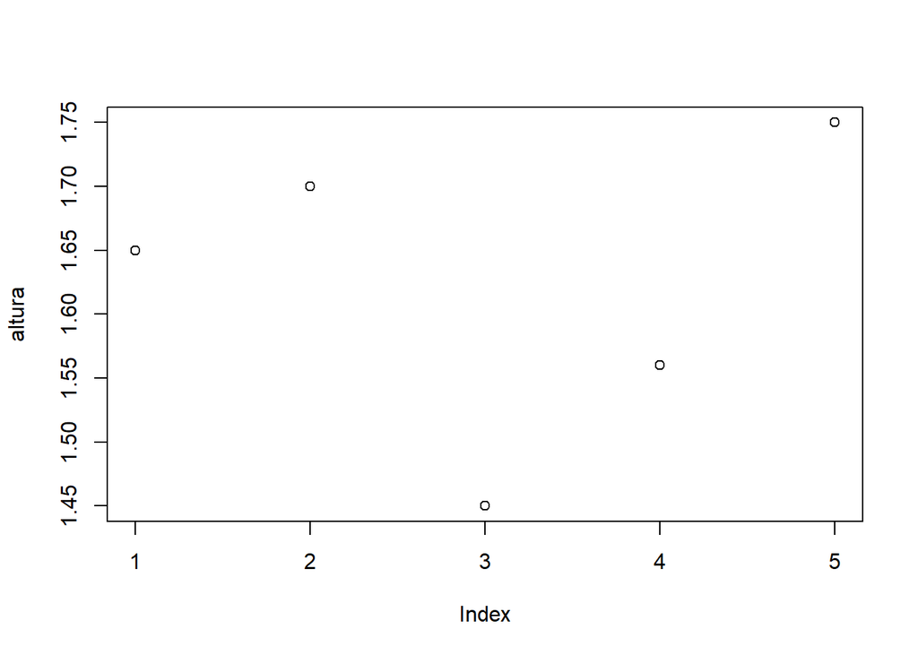

```r
plot(altura)
```

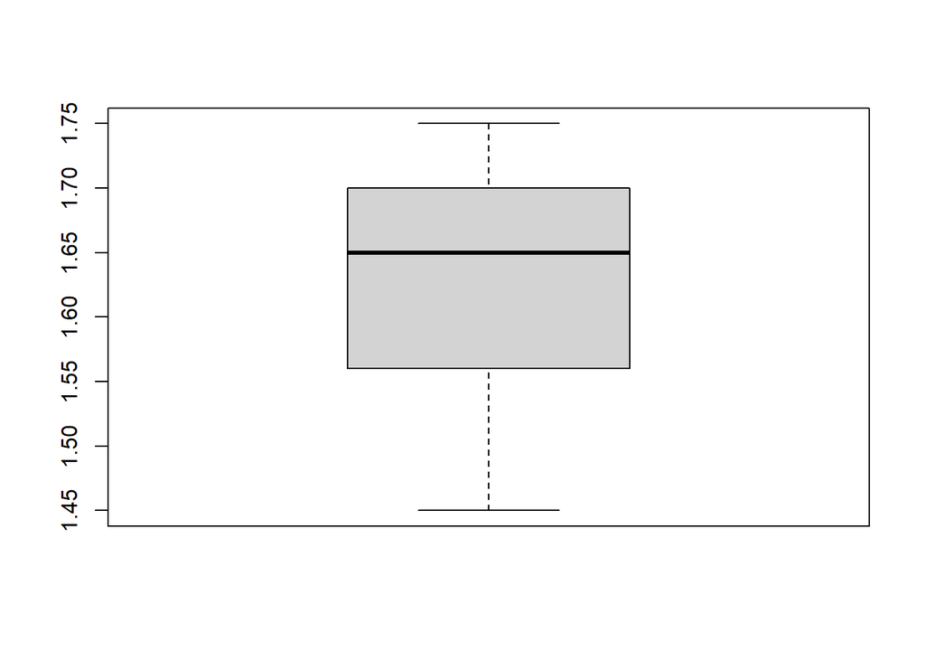

```r
boxplot(altura)
```

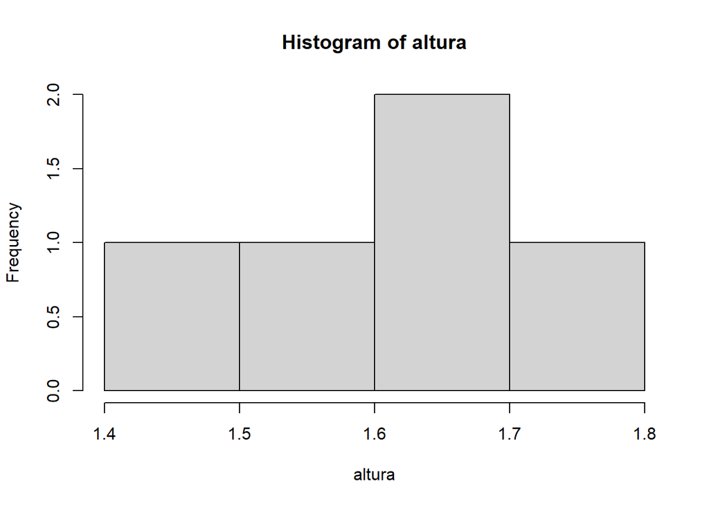

```r
hist(altura)
```

En el primer caso, tenemos un grafico que simplemente me dice las alturas El segundo es de cajas y bigotes El tercero es un histograma

```r
x11()
```

```r
tiff("Figura_altura-m.tif",
     height = 250, width = 100, units = "mm",
     res = 300)
par(mfrow = c(3, 2))
plot(altura)
plot(altm)
boxplot(altura)
boxplot(altm)
hist(altura)
hist(altm)
dev.off()
```

Tiff es una extension de archivo (como pdf), figuras tipo pixel

# Vectores de distinto tipo

```r
?rep
altura <- c(1.65, 1.70, 1.45, 1.56, 1.75)
genero <- rep(c("mujer", "hombre"), c(3,2))

typeof(genero)
```

```
## [1] "character"
```

```r
str(genero)
```

```
##  chr [1:5] "mujer" "mujer" "mujer" "hombre" "hombre"
```

```r
summary(genero)
```

```
##    Length     Class      Mode
##         5 character character
```

```r
genero <- as.factor(genero)
typeof(genero)
```

```
## [1] "integer"
```

```r
str(genero)
```

```
##  Factor w/ 2 levels "hombre","mujer": 2 2 2 1 1
```

```r
summary(genero)
```

```
## hombre  mujer
##      2      3
```

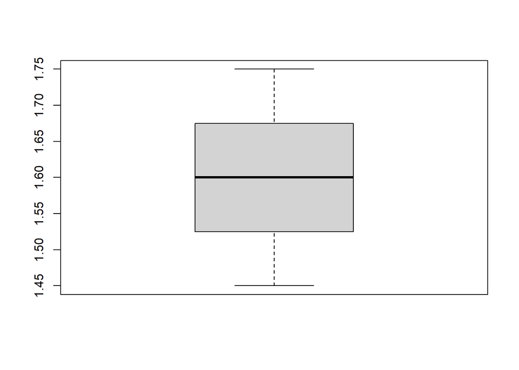

```r
?seq

seqalt <- seq(from = min(altura), to = max (altura),
    length = 1000)

boxplot(seqalt)
```

```r
seqalt4 <- matrix(data = seqalt, ncol = 4,
       byrow = FALSE)
dim(seqalt4)
```

```
## [1] 250   4
```

```r
View(seqalt4)
```

```r
length(seqalt)/4
```

```
## [1] 250
```

```r
str(seqalt4)
```

```
##  num [1:250, 1:4] 1.45 1.45 1.45 1.45 1.45 ...
```

```r
quantile(seqalt)
```

```
##    0%   25%   50%   75%  100%
## 1.450 1.525 1.600 1.675 1.750
```

```r
quantile(seqalt, 0.25)
```

```
##   25%
## 1.525
```

```r
quantile(seqalt, 0.75)
```

```
##   75%
## 1.675
```

```r
?break
?cut

c(min(seqalt),
  quantile(seqalt, 0.25), quantile(seqalt, 0.75),
  max(seqalt))
```

```
##         25%   75%
## 1.450 1.525 1.675 1.750
```

```r
c(quantile(seqalt),
  seq(0.1, by = 0.5))
```

```
##    0%   25%   50%   75%  100%
## 1.450 1.525 1.600 1.675 1.750 0.100 0.600
```

```r
kk <- cut(seqalt, breaks = c(min(seqalt),
                             quantile(seqalt, 0.25),
                             quantile(seqalt, 0.75),
                             max(seqalt)),
          labels= c("min", "med", "max"))

kk
```

```
##    [1] <NA> min  min  min  min  min  min  min  min  min  min  min  min  min
##   [15] min  min  min  min  min  min  min  min  min  min  min  min  min  min
##   [29] min  min  min  min  min  min  min  min  min  min  min  min  min  min
##   [43] min  min  min  min  min  min  min  min  min  min  min  min  min  min
##   [57] min  min  min  min  min  min  min  min  min  min  min  min  min  min
##   [71] min  min  min  min  min  min  min  min  min  min  min  min  min  min
##   [85] min  min  min  min  min  min  min  min  min  min  min  min  min  min
##   [99] min  min  min  min  min  min  min  min  min  min  min  min  min  min
##  [113] min  min  min  min  min  min  min  min  min  min  min  min  min  min
##  [127] min  min  min  min  min  min  min  min  min  min  min  min  min  min
##  [141] min  min  min  min  min  min  min  min  min  min  min  min  min  min
##  [155] min  min  min  min  min  min  min  min  min  min  min  min  min  min
##  [169] min  min  min  min  min  min  min  min  min  min  min  min  min  min
##  [183] min  min  min  min  min  min  min  min  min  min  min  min  min  min
##  [197] min  min  min  min  min  min  min  min  min  min  min  min  min  min
```

[output cut: 58 more lines]

```r
levels(kk)
```

```
## [1] "min" "med" "max"
```

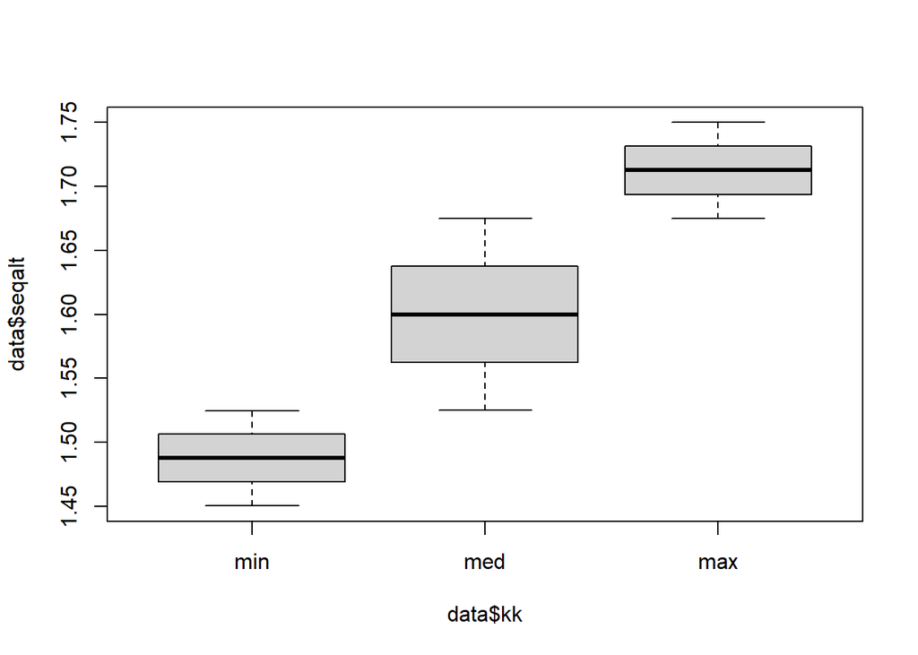

```r
data <- data.frame(seqalt,
                   kk)

View(data)

boxplot(data$seqalt ~ data$kk)
```

```r
summary(data)
```

```
##      seqalt         kk
##  Min.   :1.450   min :249
##  1st Qu.:1.525   med :500
##  Median :1.600   max :250
##  Mean   :1.600   NA's:  1
##  3rd Qu.:1.675
##  Max.   :1.750
```

Eje y ~ Eje x

# Recomendaciones basicas de trabajo

1. Entrar en “global options” y que no tengamos marcado “restaurar Rdata en un espacio de trabajo”
2. Generar un proyecto organizado
- Hacer carpetas para los distintos tipos de archivos Ejemplo: “1-datos”: con subcarpetas para tipos de datos “2-scripts” o “3-output” (o figuras)
- Nombres de los archivos Tienen que tener un significado sobre el contenido

¿Que nombre es mas correcto para un scripts que me ajusta modelos? ajuste-modelos.R o a-mod.R Es mas correcto el primero ya que es mas informativo y facil de recordar

- Si tenemos scripts que deben ejecutarse secuencialmente hay que numerarlos Ejemplo: 0-descarga.R, 1-exploracion.R, 2-AnalisisDiversidad.R
3. El codigo tenga una buena sintaxis y sea facil de leer
- Comenta el codigo para que alguien mas pueda comprenderlo o incluso uno mismo si transcurre un tiempo
- Usar nombres memorables y correctos para las variables Nombres claros, usar siempre minusculas con palabras separadas por guiones bajos (_)

¿Cual es correcta? mi_vector o MiVector o Vector.1 : mas correcta la primera

¿Para que usar nombre y para cual verbo? Nombres para variables y verbos para funciones Evitar usar nombres comunes a otras funciones y variables

- Espaciado Poner espacio despues de la coma

```r
x <- data.frame(var1 = rep(1, times = 100),
                var2 = seq(from = 1, to = 100),
                var3 = rnorm(100, mean = 3, sd = 0.5))

summary(as.factor(x$uso))
```

```
## integer(0)
```

```r
x[, 1]
```

```
##   [1] 1 1 1 1 1 1 1 1 1 1 1 1 1 1 1 1 1 1 1 1 1 1 1 1 1 1 1 1 1 1 1 1 1 1 1 1 1
##  [38] 1 1 1 1 1 1 1 1 1 1 1 1 1 1 1 1 1 1 1 1 1 1 1 1 1 1 1 1 1 1 1 1 1 1 1 1 1
##  [75] 1 1 1 1 1 1 1 1 1 1 1 1 1 1 1 1 1 1 1 1 1 1 1 1 1 1
```

```r
mean(x, na.rm = TRUE)
```

```
## [1] NA
```

Antes y despues del *=* y la flecha de asignacion *<-* hay que dejar espacio

4. Estructurar el codigo y pensar las secciones que tiene

Llamar a las librerias antes de cargar los datos Cargar los datos Analizar los datos Obtener y guardar resultados

# Instalar varias librerias

```r
install.packages(c("dplyr","ggplot2"), dep = T)
```

# Citar

```r
citation("dplyr")
```

```
##
##
##   Hadley Wickham, Romain François, Lionel Henry and Kirill Müller
##   (2022). dplyr: A Grammar of Data Manipulation. R package version
##   1.0.8. https://CRAN.R-project.org/package=dplyr
##
## A BibTeX entry for LaTeX users is
##
##   @Manual{,
##     title = {dplyr: A Grammar of Data Manipulation},
##     author = {Hadley Wickham and Romain François and Lionel Henry and Kirill Müller},
##     year = {2022},
##     note = {R package version 1.0.8},
##     url = {https://CRAN.R-project.org/package=dplyr},
##   }
```

# Importar y salvar datos

```r
datos <- data.frame(id = seq(from = 1, to = 100),
                uso = rep(c("A","B"), times = 50),
                riqueza = rnorm(100, mean = 3, sd = 0.5))
```

Con id senalo el identificador

```r
#write.csv(x, "1-datos/diversidad_uso.csv")

#datos <- read.csv("1-datos/diversidad_uso.csv")

#str(datos)
#summary(datos)
```

```r
kk <- datos[, -1]
```

# Hacer un analisis y guardamos una tabla y una figura

```r
names(datos)
```

```
## [1] "id"      "uso"     "riqueza"
```

```r
mean(datos$riqueza)
```

```
## [1] 3.048553
```

```r
summary(as.factor(datos$uso))
```

```
##  A  B
## 50 50
```

```r
maves <- tapply(datos$riqueza, datos$uso, FUN = mean)
sdaves <- tapply(datos$riqueza, datos$uso, FUN = sd)

resumen_aves <- data.frame(maves, sdaves)

#write.csv(resumen_aves,"3-resultados/resumen_aves.csv")
```

Con *tapply()*: agrupa los datos de un vector de acuerdo a otra variable categorica y una funcion Si no pongo as.factor solo tengo un caracter Senalo que datos$uso es un factor y me lo cuenta, a partir de ahi ya puedo hacer la media y la sd Con data.frame hago una tabla

```r
tiff("3-resultados/riqueza_uso.tif", height = 250, width = 100, units = "mm", res = 300)
boxplot(datos$riqueza ~ datos$uso)
dev.off()
```

# R Markdown

Es un lenguaje de marcado, tiene etiquetas o marcas que contienen informacion adicional sobre la estructura del texto o su presentacion Es un lenguaje y una herramienta de software el lenguaje en HTML valido Genera documentos dinamicos En el boton Knit (compilador) ves como queda en HTML

# Gis

Funcionan por capas Las distintas capas no puede mezclarse (poligonales con puntos por ejemplo) La resolucion raster es el tamano del pixel Datos vectoriales o raster Los archivos shape file se componen de cinco archivos (se llaman de la misma forma pero tienen extensiones distintas) netCDF ocupan muchas capas Se basan en sistemas de coordenadas

# Graficos

Histograma: eje x y eje y, no permite ver si hay una relacion entre ellas, diagrama de barras, los datos centrales son los que mas se repiten (solo con una variable, y = frecuencia) Scotterplots: nube de puntos con smooth (linea de tendencia) Boxplots: grafico de dispersion, permite ver como varian los datos

Paquete tidyverse: los datos se tienen en vertical Cada columna es una variable y cada fila una observacion

Estructura:

X <- ggplot(object, aes(var_x, var_y))+ geom_typeofplot(alpha = , size = , color = , fill = )+ geom_smooth()+ theme_tipodetema()

```r
#kk <- ggplot(data, aes(var_date, var_number))+
#  geom_point(color = "orangered", size = "5", alpha = 0,5)+
#  theme_classic()
```

*aes* es una forma de decir que acceda al interior de mi base de datos Luego mencionamos el tipo de grafica que queramos: geom_point/bar/… alpha es la transferencia, es un valor que oscila entre 0 y 1

# Problema Volcan

```r
#install.packages("tidyverse")
#install.packages("lubridate")
#install.packages("ggthemes")
#install.packages("wesanderson")
library(tidyverse)
library(lubridate)
library(ggthemes)
library(wesanderson)
```

```r
count_cumbre_vieja <- read.csv("../cumbre_vieja_visualdata-main/count_cumbre_vieja.csv")
data_cumbre_vieja <- read.csv("../cumbre_vieja_visualdata-main/data_cumbre_vieja.csv")
count_cumbre_vieja$date <-  as.Date(count_cumbre_vieja$date)
```

Si no pongo *as.Date*, no me lo reconoce como si fuesen fechas

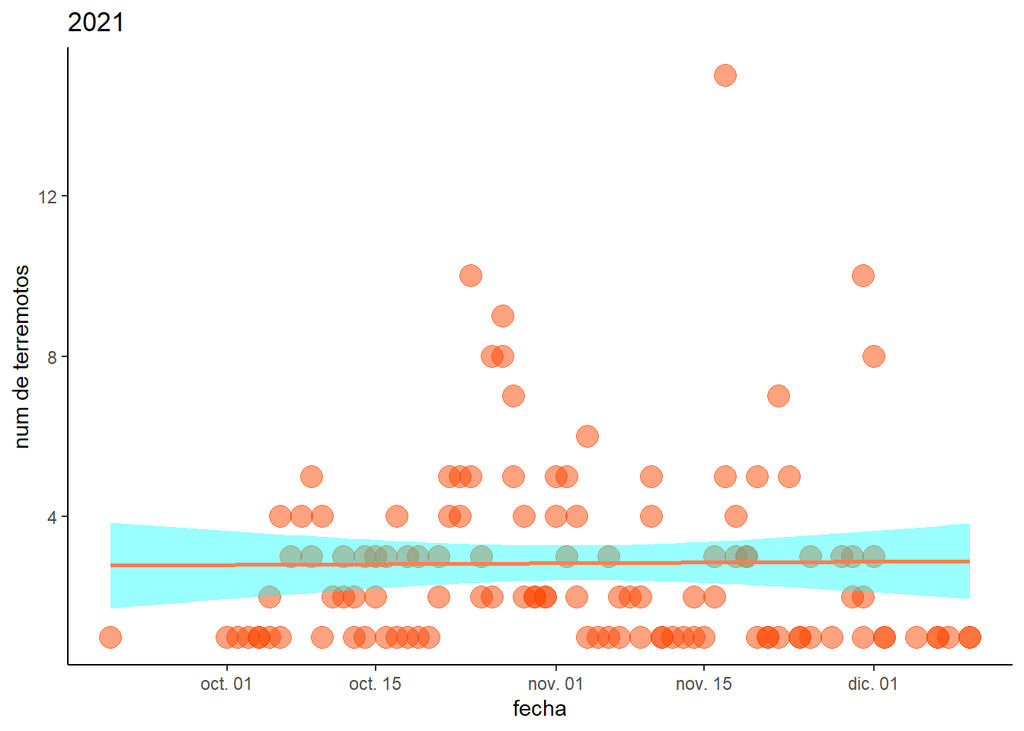

```r
earthquakes_date <- ggplot(data = count_cumbre_vieja, aes(x = date, y = number))+
  geom_point(color = "orangered",
             size = 5,
             alpha = 0.5
             )+
  geom_smooth(color = "coral",
              fill = "cyan",
              method = "lm"
                )+
  labs(x = "fecha",
       y = "num de terremotos",
       title = "2021")+
  theme_classic()

earthquakes_date
```

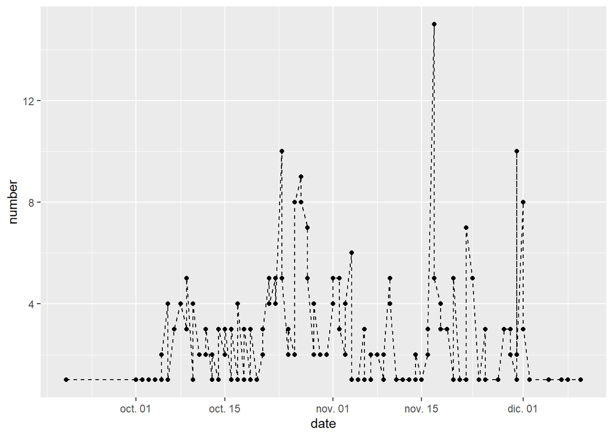

```r
earthquakes_date2 <- earthquakes_date+
  geom_line(linetype = "dashed",
            color = "cyan2")

ggplot(count_cumbre_vieja, aes(x = date, y = number))+
  geom_line(linetype = "dashed")+
  geom_point()
```

Con *lm* señalo que es un modelo lineal con *labs* cambio los nombres de los ejes de la grafica Con *geom_line*, **linetype** cambio el tipo de lineas

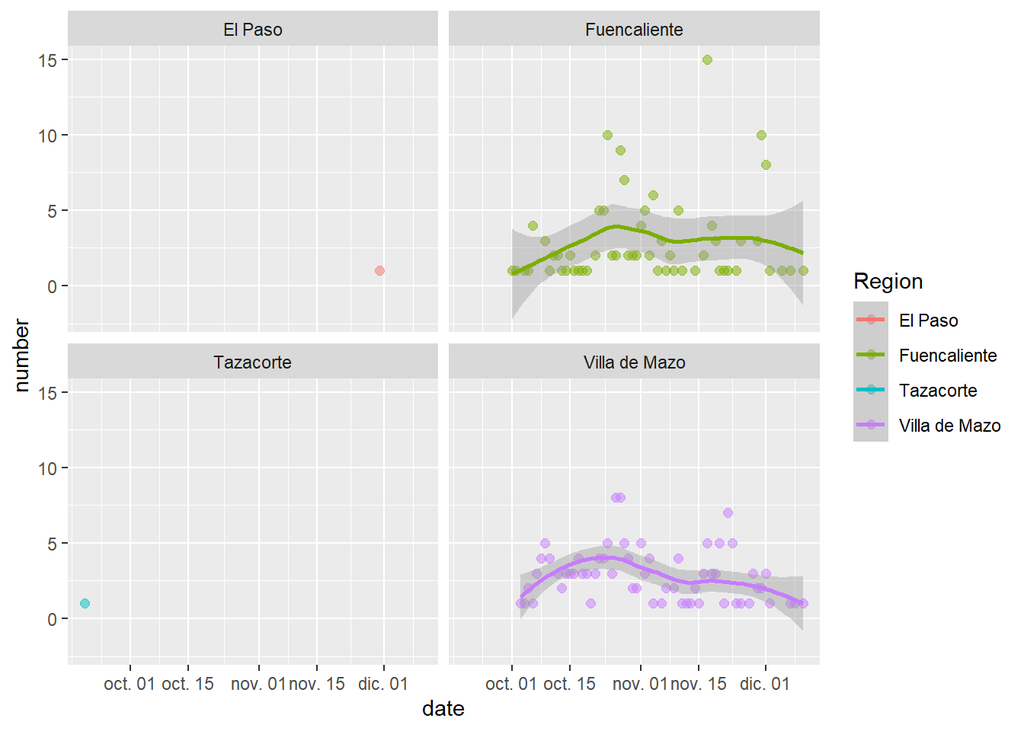

```r
earthquakes_date <- ggplot(data = count_cumbre_vieja, aes(x = date, y = number))+
  geom_point(aes(color = Region),
             size = 2,
             alpha = 0.5)+
  geom_smooth(aes(color = Region))

earthquakes_date+
  facet_wrap(.~ Region)
```

Con geom_smooth(aes(color = Region)) pongo una linea de tendencia diferente a cada region Con facet_wrap(.~ Region) divido la grafica en funcion de lo que quiera

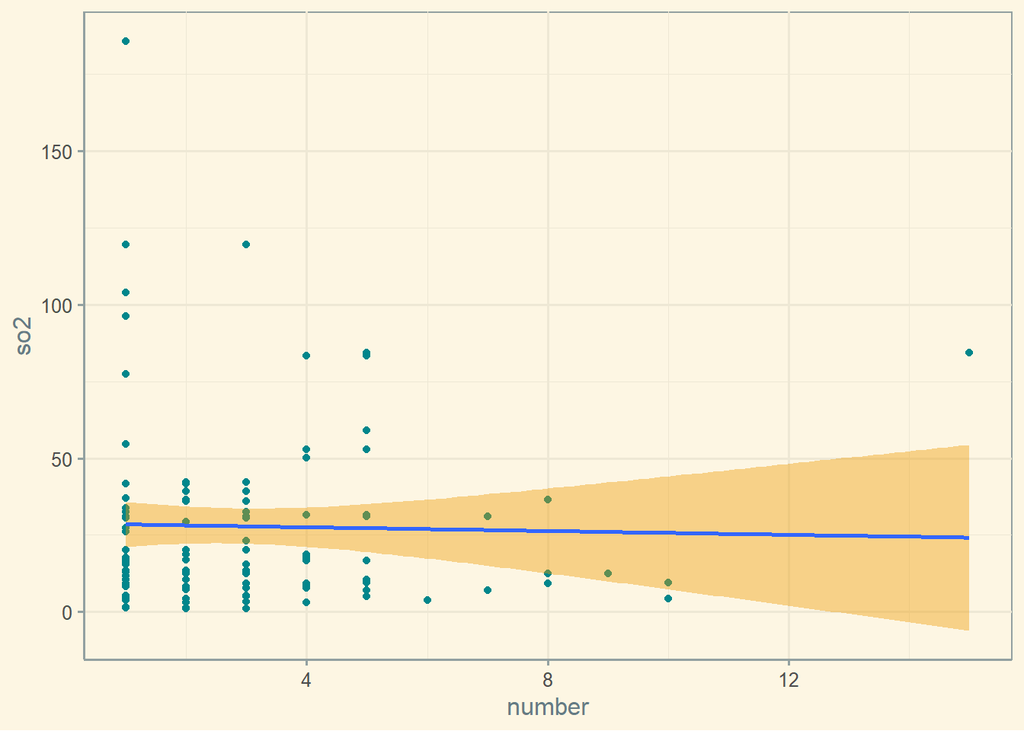

```r
ggplot(data = count_cumbre_vieja, aes(x = number, y = so2))+
  geom_point(color = "turquoise4")+
  geom_smooth(method = "lm",
              fill = "orange2")+
  theme_solarized()
```

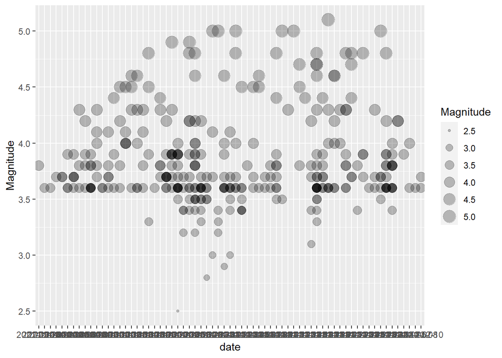

```r
ggplot(data = data_cumbre_vieja, aes(x = date, y = Magnitude))+
  geom_point(aes(size = Magnitude),
             alpha = 0.25)+
  geom_smooth()
```

Si anado un - antes de la variable me lo hace a la inversa (en vez de a mayor magnitud, a menor) Si queremos representar una tercera variable que no aparece en la grafica para visualizarlo tiene que ser numerica

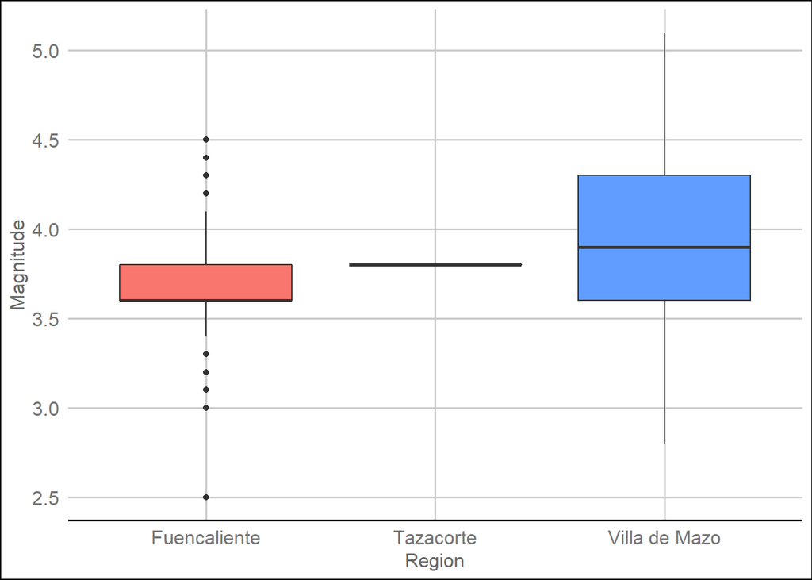

```r
ggplot(data = data_cumbre_vieja, aes(x = Region, y = Magnitude))+
  geom_boxplot(aes(fill = Region))+
  theme_gdocs()+theme(legend.position = "none")
```

Pongo fill en lugar de color porque es un area Con legend.position = “none” quito la leyenda si no da informacion necesaria Anadir las personalizaciones al final

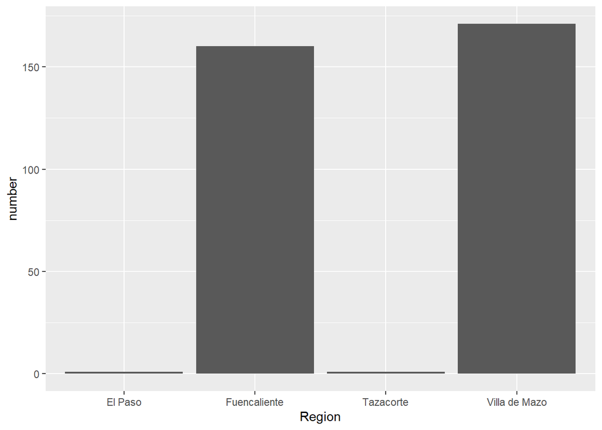

```r
ggplot(data = count_cumbre_vieja, aes(x = Region, y = number))+
  geom_bar(stat = "identity")
```

# Introduccion a Tidyverse

Con *here()* nos dice la carpeta en la que estamos Con *read.csv(“../01-data/co2.csv”)* los “..” nos sirven para leer un archivo que se encuentra en otra carpeta En cambio, en tidyverse se haria asi: *read_csv(here(“01-data”, “co2.csv”))*

Para ver las primeras columnas, usamos: *head(co2data)* La funcion *glimpse()* hace que se vea mas ordenado

Caracteristicas de de “tidy data”: - Toda columna es una variable - Toda fila es una observacion - Cada celda es una medida unica

Tecla rapida para insertar la pipa *%>%* : CNTRL + SHIFT + M

En el caso de: *temdata %>% select(!ID_coords)* con la **!** filtro todas menos una

```r
#temp_sel %>%
#  mutate(Tmean = (Tmax + Tmin)/2,
#        date = as.Date(date),
#         month = format(date, format = "%m"),
#         year = format(date, format = "%Y")
#         )
```

Con *mutate* creo una variable nueva A veces, con esta funcion, tenemos que indicar el tipo que es: - year = *as.numeric*(year) Ademas con *month* y *year* puedo separar por formato mes/anyo

```r
#yearly_temp <- temp_mean %>%
#  group_by(year) %>%
#  summarise(
#    Tmean.year = mean(Tmean)
#  )
```

Con *group_by()* en el caso indicado, estamos agrupando por anyos A continuacion con *summarise()* y *mean* hacemos la media de la temperatura en el anyo

```r
#full_join(
#  yearly_temp, co2data_l_sp, by = c("year" = "co2_year")
#)
```

con *full_join* estariamos uniendo dos tablas Otra pisibilidad es hacerlo con *merge()*

# Forcats

*Stringr*: vectores compuestos por caracteres - Se filtra y extrae la informacion interesante *Forcats*: las variables pueden ser numericas y factores - Con distintos niveles de tratamiento

# Purrr

Para trabajar con funciones Repetir una tarea muchas veces de forma automatica

# Creacion de graficos

```r
#grafica_final <- (gg_ye_co_th + gg_ye_co_sec_th) /
#  (gg_ye_temp_th + gg_co_temp_th) +
#  plot_annotation(
#    title = expression(paste("Annual mean temperature and "~CO[2], " emissions relationship over the years in Alcalá de Henares, #Madrid (1950-2020)")),
#    caption = "   Data source:
#    Graphic: Students and teachers of **Ciencia de Datos Práctica: Resolución de Problemas Ambientales Mediante Proyectos #(Universidad de Alcalá)** course",
#    theme = theme(
#      plot.title = element_text(size = 24, face = "bold"),
#      plot.caption = element_text(hjust = 0, size = 14, color = "grey50", margin = margin(t = 25))
#      )
#    )

#ggsave(
#  plot = grafica_final,
#  here("03-figures", "alcala_co2_temp.png"),
#  width = 20, height = 14
#  )
```

Graficas que van en la parte superior / graficas de la parte inferior Se puede anadir un pie de foto con datos de las referencias, del autor… con *caption* Con *“~CO[2],”* podemos insertar subindices

Con *ggsave* guardamos la grafica que acabamos de crear

De un script muy largo podemos tener uno mas pequeño con: *source(here(“02-functions”, “f_read_data.R”))*

# Referencias

Se senalarian asi:

Ciencia de Datos Práctica: Resolución de Problemas Ambientales Mediante Proyectos (Universidad de Alcalá)

# Compilar

Se utiliza el botón de “*Knit*” (teclas rapidas: Ctrl + Shift + K) También se puede hacer mediante código: rmarkdown::render(“intro_repro.Rmd”, output_dir = “output”)

# Eliminar objetos de la memoria

rm(list=ls())

# Asignamos el directorio

setwd() O con el atajo: CNTRL + SHIFT + H

# Mapa de los paises

```r
#install.packages("maptools")
#install.packages("rgdal")
#install.packages("dismo")
#install.packages("spam")
#install.packages("jsonlite")
#install.packages("rgeos")
#install.packages("mapSpain")
#install.packages("ggmap")
#install.packages('maps')
#install.packages('mapdata')
#install.packages("marmap")
#install.packages("mapproj")
#install.packages("sf")

library(raster)
library(maptools)
library(sp)
library(sf)
library(rgdal)
library(dismo)
library(spam)
library(jsonlite)
library(rworldmap)
library(rworldxtra)
library(rgeos)
library(mapSpain)
library(ggmap)
library(ggplot2)
library(maps)
library(mapdata)
library(marmap)
library(mapproj)


mapamundo <- getMap(resolution="high")
head(mapamundo)
```

[output not shown]

[output cut: 55 more lines]

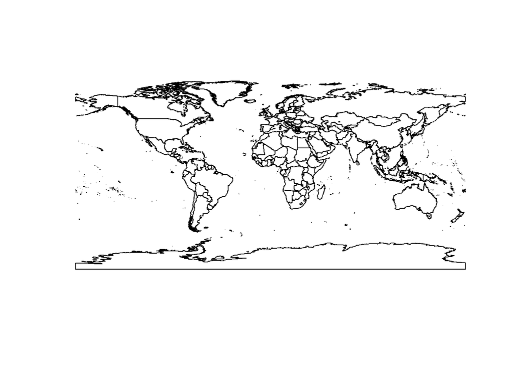

```r
plot(mapamundo)
```

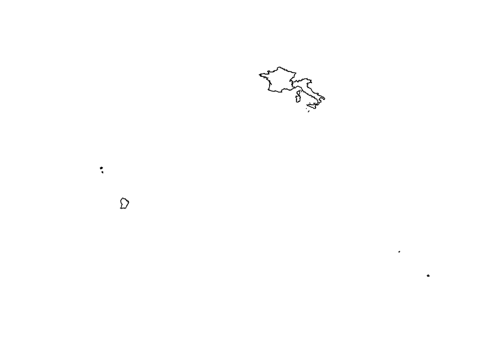

```r
mapaspain <- mapamundo["Spain",]

mapaitaliafrancia <- mapamundo[c('Italy','France'),]
plot(mapaitaliafrancia)
```

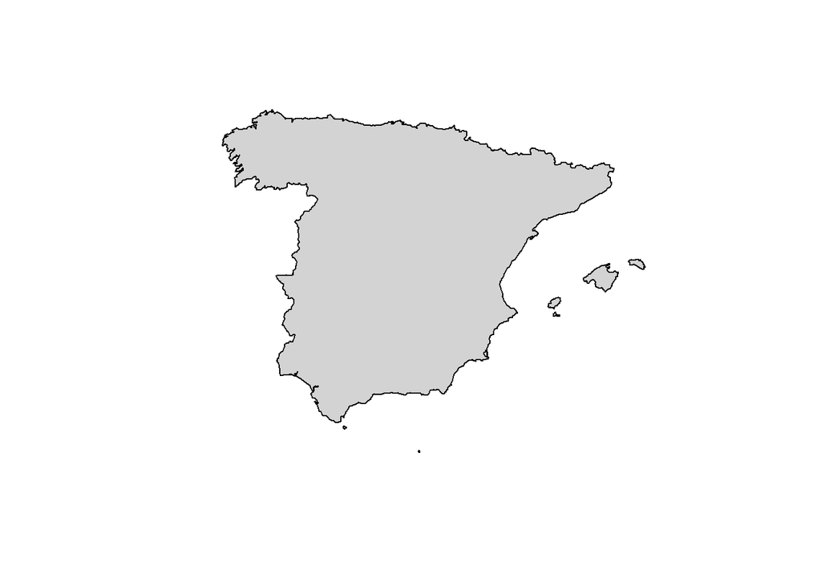

```r
mapaspain <- crop(mapaspain, extent(-10,5,35,45))

plot(mapaspain, col="lightgrey", border="black")
```

Si pongo “c” antes de los paises puedo anadir mas de uno Uso **crop** para recortar el mapa con las coordenadas que yo quiera, en este caso para la peninsula y baleares

Si usamos **mapDevice()** podemos ver los mapas en una ventana aparte

```r
#map("world", fill=TRUE
#    ,col="grey65"
#    ,boundary=F,interior=F
#    ,ylim=c(-60, 65), mar=c(0,0,0,0)
#    ,projection='albers',par=c(0,0),wrap=T
#    ,resolution=1,border="lightgrey",myborder=0)
```

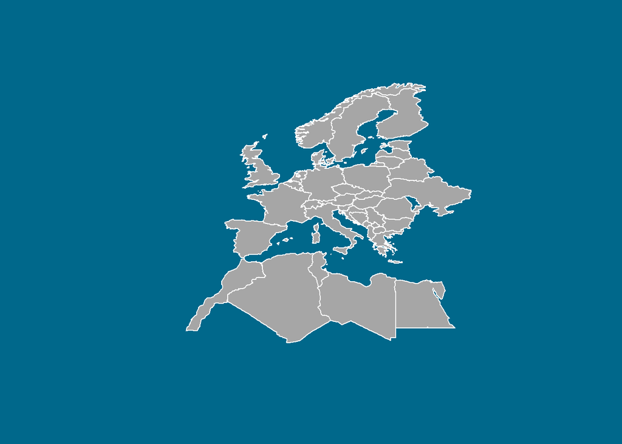

```r
map("world", fill=TRUE
    ,col="grey65"
    ,bg="deepskyblue4"
    ,boundary=F,interior=F
    ,ylim=c(30, 65),xlim=c(-5,25), mar=c(0,0,0,0)
    ,projection='albers',par=c(0,0),wrap=T
    ,resolution=0,border="white",myborder=0)
```

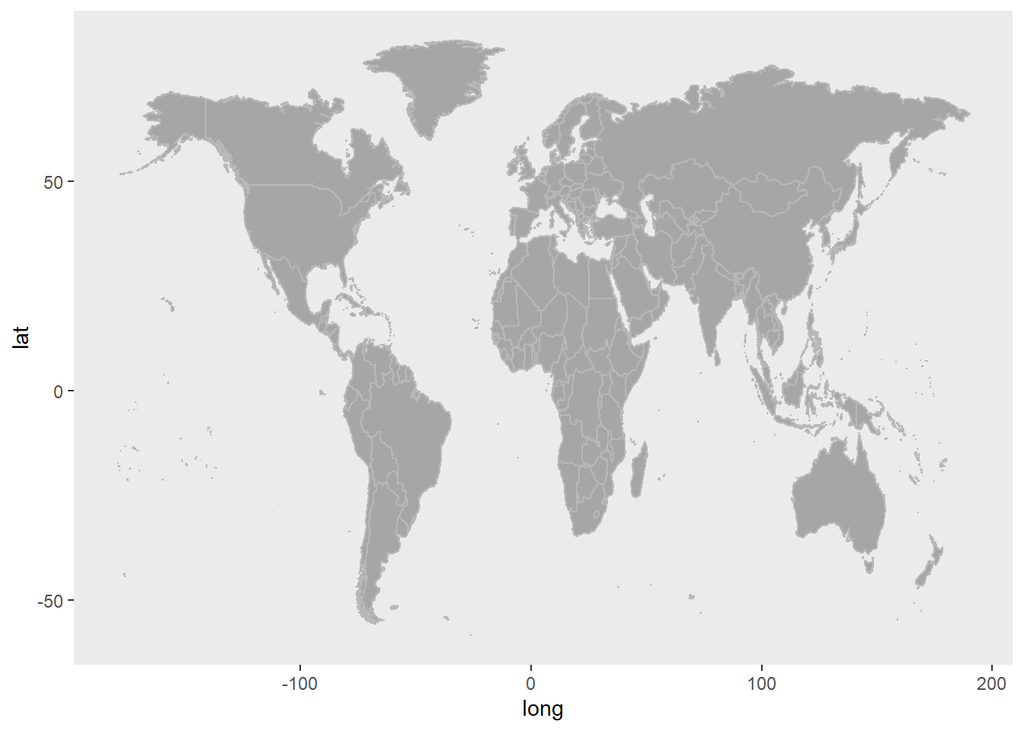

```r
mapWorld <- borders("world", colour="gray72", fill="gray65",
                    ylim=c(-60,60),xlim=c(-180,180))
mp <- ggplot() +   mapWorld
mp + theme(panel.border = element_blank(),
           panel.grid.major = element_blank(),
           panel.grid.minor = element_blank())
```

```r
#BATHYMET<-getNOAA.bathy(lon1=45,lon2=-15,lat1=65,lat2=30, resolution=5)

blues <- c("lightsteelblue4", "lightsteelblue3",
           "lightsteelblue2", "lightsteelblue1")


#plot(BATHYMET, image = TRUE, land = TRUE, lwd = 0.05,lty=0,
#     ylim=c(30,65),xlim=c(-8,35),
#     bpal = list(c(0, max(BATHYMET), "lightsteelblue1"),
#                 c(min(BATHYMET),0,blues)),add=F)
```

```r
mapaspain
```

```
## Object of class "SpatialPolygonsDataFrame" (package sp):
##
## Number of SpatialPolygons:  1
##
## Variables measured:
##       ne_10m_adm ScaleRank LabelRank    FeatureCla OID_ SOVEREIGNT SOV_A3
## Spain        ESP         1         2 Adm-0 country  233      Spain    ESP
##       ADM0_DIF LEVEL              TYPE ADMIN ADM0_A3 GEOU_DIF GEOUNIT GU_A3
## Spain        0     2 Sovereign country Spain     ESP        0   Spain   ESP
##       SU_DIF SUBUNIT SU_A3  NAME ABBREV POSTAL       NAME_FORMA TERR_ NAME_SORT
## Spain      0   Spain   ESP Spain    Sp.      E Kingdom of Spain  <NA>     Spain
##       MAP_COLOR  POP_EST GDP_MD_EST FIPS_10_ ISO_A2 ISO_A3 ISO_N3 ISO3
## Spain         5 40525002    1403000        0     ES    ESP    724  ESP
##             LON      LAT ISO3.1 ADMIN.1 REGION continent GEO3major
## Spain -3.565944 40.40002    ESP   Spain Europe   Eurasia    Europe
##                 GEO3        IMAGE24 GLOCAF  Stern SRESmajor
## Spain Western Europe Western Europe Europe Europe    OECD90
##                       SRES             GBD AVOIDnumeric AVOIDname   LDC   SID
## Spain Western Europe (WEU) Europe, Western           25    Europe other other
##        LLDC
## Spain other
```

```r
#altSpain <- getData('alt', country='ESP', mask=T)


#plot(altSpain)


#alt2 = altSpain
#res(alt2) = 0.02166666

#alt3 <- resample(altSpain,alt2,method='bilinear')
#plot(alt3)


#slope <- terrain(alt3, opt='slope')
#aspect <- terrain(alt3, opt='aspect')
#hill <- hillShade(slope, aspect, 30, 250, normalize=T)
#plot(hill, col=adjustcolor(grey(0:100/100),0.8), legend=FALSE, add=F)
```

```r
census <- pobmun19
#census <- mapSpain::pobmun19

codelist <- esp_codelist
#codelist <- mapSpain::esp_codelist
str(codelist)
```

```
## 'data.frame':    59 obs. of  44 variables:
##  $ nuts1.code        : chr  "ES1" "ES1" "ES1" "ES1" ...
##  $ nuts1.name        : chr  "NOROESTE" "NOROESTE" "NOROESTE" "NOROESTE" ...
##  $ nuts1.name.alt    : chr  "Noroeste" "Noroeste" "Noroeste" "Noroeste" ...
##  $ nuts1.shortname.es: chr  "Noroeste" "Noroeste" "Noroeste" "Noroeste" ...
##  $ codauto           : chr  "03" "06" "12" "12" ...
##  $ iso2.ccaa.code    : chr  "ES-AS" "ES-CB" "ES-GA" "ES-GA" ...
##  $ nuts2.code        : chr  "ES12" "ES13" "ES11" "ES11" ...
##  $ ine.ccaa.name     : chr  "Asturias, Principado de" "Cantabria" "Galicia" "Galicia" ...
##  $ iso2.ccaa.name.es : chr  "Asturias, Principado de" "Cantabria" "Galicia" "Galicia" ...
##  $ iso2.ccaa.name.ca : chr  NA NA NA NA ...
##  $ iso2.ccaa.name.gl : chr  NA NA "Galicia" "Galicia" ...
##  $ iso2.ccaa.name.eu : chr  NA NA NA NA ...
##  $ nuts2.name        : chr  "Principado de Asturias" "Cantabria" "Galicia" "Galicia" ...
##  $ cldr.ccaa.name.en : chr  "Asturias" "Cantabria" "Galicia" "Galicia" ...
```

[output cut: 30 more lines]

```r
census <- unique(merge(census, codelist[, c("cpro", "codauto")], all.x = TRUE))

census_ccaa <-
  aggregate(cbind(pob19, men, women) ~ codauto, data = census, sum)

census_ccaa$porc_women <- census_ccaa$women / census_ccaa$pob19
census_ccaa$porc_women_lab <-
  paste0(round(100 * census_ccaa$porc_women, 2), "%")

census_ccaa$porc_men <- census_ccaa$men / census_ccaa$pob19
census_ccaa$porc_men_lab <-
  paste0(round(100 * census_ccaa$porc_men, 2), "%")

census_ccaa
```

```
##    codauto   pob19     men   women porc_women porc_women_lab  porc_men
## 1       01 8414240 4147167 4267073  0.5071252         50.71% 0.4928748
## 2       02 1319291  650694  668597  0.5067851         50.68% 0.4932149
## 3       03 1022800  488137  534663  0.5227444         52.27% 0.4772556
## 4       04 1149460  572757  576703  0.5017165         50.17% 0.4982835
## 5       05 2153389 1065971 1087418  0.5049798          50.5% 0.4950202
## 6       06  581078  281801  299277  0.5150376          51.5% 0.4849624
## 7       07 2399548 1181401 1218147  0.5076569         50.77% 0.4923431
## 8       08 2032863 1016954 1015909  0.4997430         49.97% 0.5002570
## 9       09 7675217 3770123 3905094  0.5087927         50.88% 0.4912073
## 10      10 5003769 2465342 2538427  0.5073030         50.73% 0.4926970
## 11      11 1067710  528500  539210  0.5050154          50.5% 0.4949846
## 12      12 2699499 1298964 1400535  0.5188129         51.88% 0.4811871
## 13      13 6663394 3187312 3476082  0.5216684         52.17% 0.4783316
## 14      14 1493898  747615  746283  0.4995542         49.96% 0.5004458
```

[output cut: 25 more lines]

Con *aggregate* agregamos los valores por comunidad autonoma Con **paste0** “%”, calculamos los porcentajes

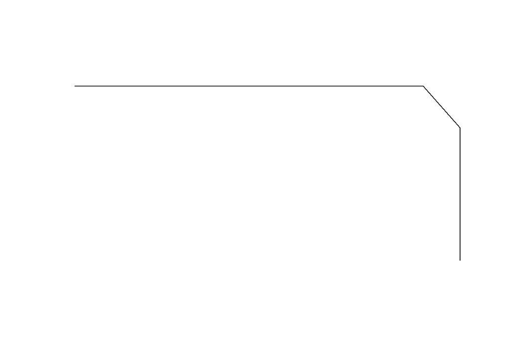

```r
Can <- esp_get_can_box()
plot(Can)
```

Para añadir esta nueva “caja” que hemos dibujado al resto del mapa que ya tenemos, en plot tendriamos que escribir: “Can, add = T”

```r
#lynx <- gbif("Lynx", "pardinus")
#lynx

#pres.lynx <- subset(lynx, select=c("country", "lat", "lon"))
#head(pres.lynx)

#pres.lynx <- subset(pres.lynx, pres.lynx$lat<90)

#par(mar=c(0.5,0.5,0.5,0.5))
#newmap <- getMap(resolution = "high")
#plot(newmap, col="lightgrey", border="white", xlim=c(-7,3), ylim=c(34,45))
#points(pres.lynx$lon, pres.lynx$lat,
#       pch=19,cex=1,col=adjustcolor("cyan4",0.15))
#text(0,45,substitute(italic("Lynx pardinus")),cex=2)
```

Hacemos un **subset** y lo convertimos en un data.frame En el caso de **points**, senalo la *x* a la *izquierda* y la *y* a la *derecha* El simbolo $ senala columnas